# Comparing measures of diversity

Emma Fuller

January 18, 2015

Previous work has found that revenue diversity is associated with less revenue variability for commercial fishermen on the US west coast. We are interested in what conditions enable or constrain vessels from participating in multiple fisheries. In particular, we are interested in what port-level characteristics are associated with diversity of revenue. We make the assumption that a vessel’s diversity is related in some way to the fisheries system in which they participate. To do this, we need to relate a vessel’s individual fisheries diversity to a port.

Here I’m comparing how port-level measures of diversity compare to vessel-level measures. First I need to figure out the right way to calculate port-level diversity. And then I’ll compare that to vessel-derived port diversity and network-diversity.

### Port level diversity

Port level diversity is calculated by taking all the trips landed at that port, and calculating the Simpsons Diversity Index based on revenue. The first question is whether it matters if I aggregate all trips across 5 years and calculate diversity versus calculating a yearly diversity and averaging across.

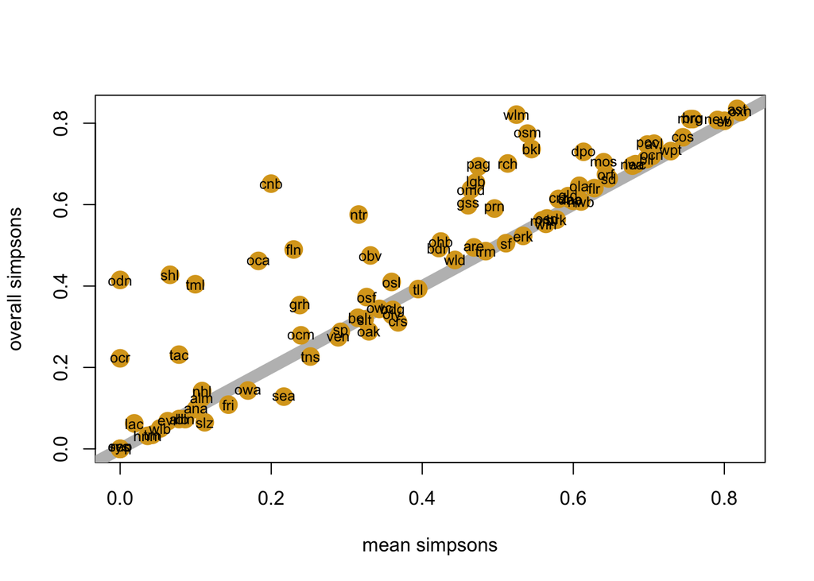

Here `overall simpsons` is calculating a single diversity measure for a single vessel based on trips across all years and `mean simpsons` is calculating a yearly diversity measure and averaging across years. Each point is a port. Taking the average each year will be conservative. This makes sense, as you could participate in fisheries $A$, $B$ in the first year and $C$ and $D$ in the second. In the `mean simpsons` calculation, those would be equivalent, but the `overall simpsons` would be higher.

I think that smaller ports are more likely to have a higher overall simpsons than a mean, since a few vessels landing or not can change dramatically the number of fisheries present.

**Conclusion**: I’ll use `mean simpsons` because it’s more conservative.

### Comparing mean port-level diversity: as derived from aggregate trips or aggregate vessels

Here I’m calculating and comparing how diversity calculated from an aggregate of vessel measures compares to one which does not consider vessel identity. The vessel level diversity is calculated for each port by finding all vessels which derive at least 50% of their revenue from that port (so vessels can only belong to one port – unless perfectly split), and taking the average of their mean diversity index.

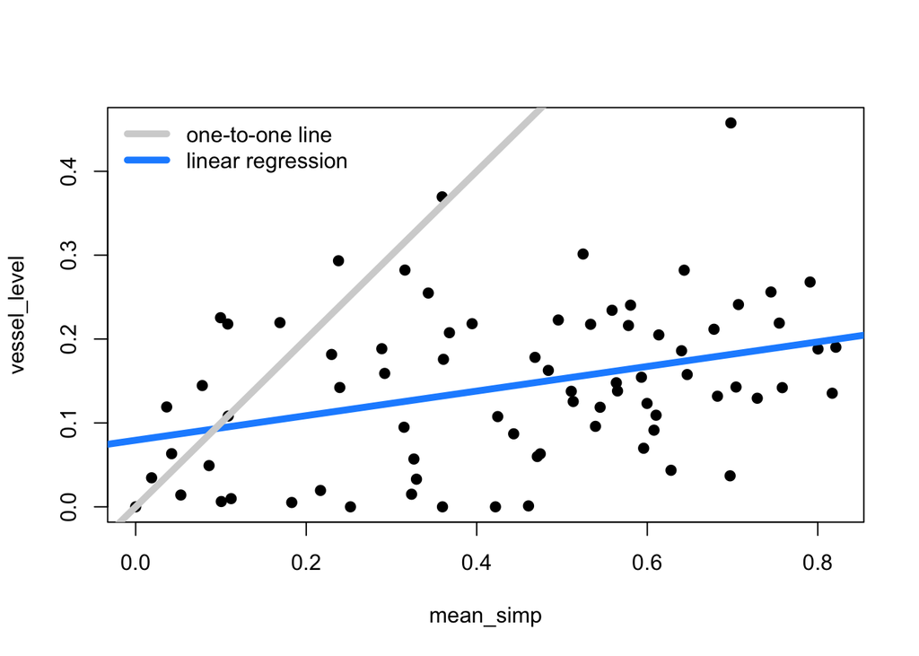

|  | Estimate | Std. Error | t value | Pr(>\|t\|) |
| --- | --- | --- | --- | --- |
| **mean_simp** | 0.1466 | 0.04551 | 3.221 | 0.0019 |
| **(Intercept)** | 0.07938 | 0.02255 | 3.52 | 0.0007426 |

Fitting linear model: vessel_level ~ mean_simp

| Observations | Residual Std. Error | $R^2$ | Adjusted $R^2$ |
| --- | --- | --- | --- |
| 76 | 0.09015 | 0.123 | 0.1111 |

There is a postive relationship between port-level diversity and vessel level diversity.

So these measures might be used to infer different things about the port. The vessel-level measure is the present reality for fishermen, but the port-level is the potential diversity that is possible.

### Conclusions

When relating port-level characteristics, what I should use is the vessel level diversity. This is because what I’m interested in is the present amount of diversity, not the potential diversity of the port. But the potential diversity of the port should be considered if I’m going to think about how management might address any low-diversity ports. As in, is there “latent diversity” present? Or do you need to bring new fisheries in?

### Comparing port-level, vessel-level and network metrics

Next I construct the participation networks for each port, each year. For each year I calculate the effective connectance, and take average across those yearly effective connectance values. I construct the participation networks with 95, 99 and no restriction on fisheries.

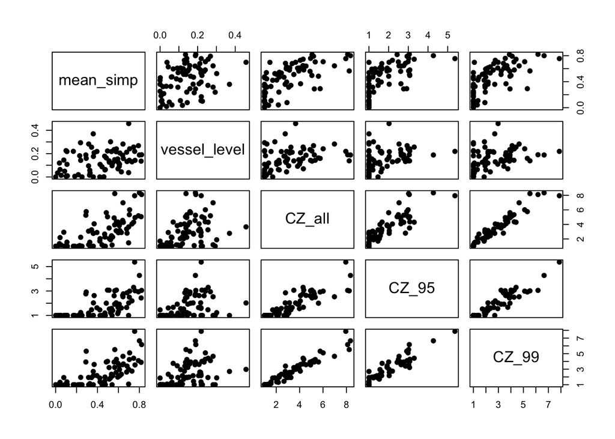

From these `pairs()` plots, I see the following

- the effective connectance (`CZ` varients) are highly correlated with one another. We would expect that. There are fewer points in the `CZ_95` and `CZ_99`, because more ports don’t have a measure for a year because all fisheries have been dropped.
- The relationship between `CZ_all` and `vessel_level` has a number of ports for which the vessel metric is higher than the `CZ`. Interested to know which ports those are.
- Similar relationship between `CZ` and `mean_simp`. What’s going on there?

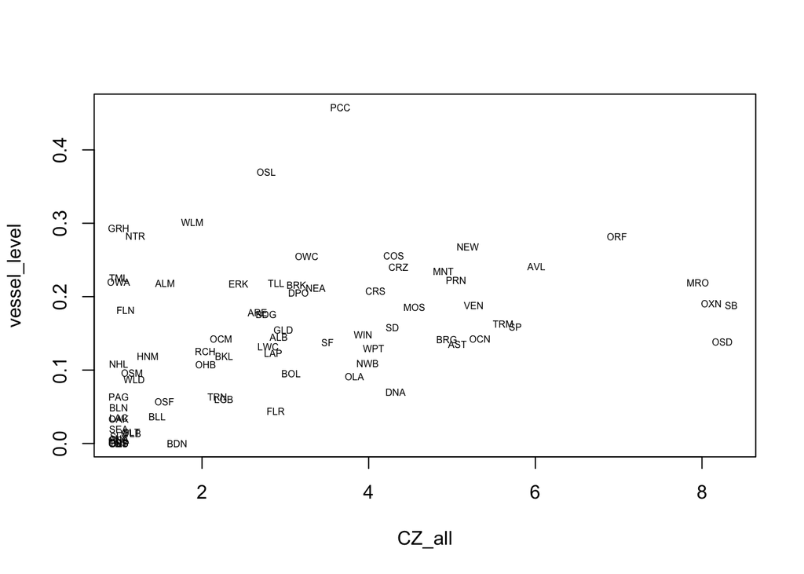

- SB here really exemplifies what `CZ` might add. At an individual vessel level, vessels only partipate in a few fisheries. But all those fisheries are interconnected. So the `CZ` score is much higher. This would like be a port where `mean_simp` was more aligned with `CZ`. And indeed when you compare CZ and `vessel_simp` you see a plataeu along the `vessel_simp` axis. Although there is also the reciprocal with some ports with the same `vessel_simp` getting a range of `CZ` values.

```r
write.csv(merged_ports, "port_metrics.csv")
# put together yearly dataset
yearly <- merge(particp_nets, port_yr_simpsons, by = c("pcid","year"))
yearly <- merge(yearly, port_vessel_diversity, by = c("pcid","year"))
colnames(yearly)[which(colnames(yearly)=="V1")] = "mean_simp"
write.csv(yearly, "/Users/efuller/1/CNH/Analysis/Metiers/results/2015-01-18/by_year_port_metrics.csv")
```